# Risk Factor Analysis

## Outcome Variable

**Outcome Variable:** whz

## Predictor Variables

**Intervention Variable:** cleanck

**Adjustment Set:**

- arm
- sex
- W_mage
- meducyrs
- feducyrs
- hhwealth_quart
- W_nrooms
- W_nhh
- W_nchldlt5
- trth2o
- impfloor
- delta_meducyrs
- delta_feducyrs
- delta_hhwealth_quart
- delta_W_nrooms
- delta_W_nhh
- delta_W_nchldlt5
- delta_trth2o
- delta_impfloor

## Stratifying Variables

The analysis was stratified on these variable(s):

- agecat
- studyid
- country

## Data Summary

| agecat | studyid | country | cleanck | n_cell | n | outcome_variable |
| --- | --- | --- | --- | --- | --- | --- |
| Birth | ki0047075b-MAL-ED | PERU | 1 | 1 | 2 | whz |
| Birth | ki0047075b-MAL-ED | PERU | 0 | 1 | 2 | whz |
| Birth | ki1000108-CMC-V-BCS-2002 | INDIA | 1 | 37 | 86 | whz |
| Birth | ki1000108-CMC-V-BCS-2002 | INDIA | 0 | 49 | 86 | whz |
| Birth | ki1000108-IRC | INDIA | 1 | 198 | 337 | whz |
| Birth | ki1000108-IRC | INDIA | 0 | 139 | 337 | whz |
| Birth | ki1017093b-PROVIDE | BANGLADESH | 1 | 433 | 532 | whz |
| Birth | ki1017093b-PROVIDE | BANGLADESH | 0 | 99 | 532 | whz |
| Birth | ki1017093c-NIH-Crypto | BANGLADESH | 1 | 336 | 543 | whz |
| Birth | ki1017093c-NIH-Crypto | BANGLADESH | 0 | 207 | 543 | whz |
| Birth | ki1113344-GMS-Nepal | NEPAL | 1 | 9 | 570 | whz |
| Birth | ki1113344-GMS-Nepal | NEPAL | 0 | 561 | 570 | whz |
| 6 months | ki0047075b-MAL-ED | SOUTH AFRICA | 1 | 1 | 1 | whz |
| 6 months | ki0047075b-MAL-ED | SOUTH AFRICA | 0 | 0 | 1 | whz |
| 6 months | ki1000108-CMC-V-BCS-2002 | INDIA | 1 | 162 | 368 | whz |
| 6 months | ki1000108-CMC-V-BCS-2002 | INDIA | 0 | 206 | 368 | whz |
| 6 months | ki1000108-IRC | INDIA | 1 | 229 | 398 | whz |
| 6 months | ki1000108-IRC | INDIA | 0 | 169 | 398 | whz |
| 6 months | ki1017093b-PROVIDE | BANGLADESH | 1 | 497 | 603 | whz |
| 6 months | ki1017093b-PROVIDE | BANGLADESH | 0 | 106 | 603 | whz |
| 6 months | ki1017093c-NIH-Crypto | BANGLADESH | 1 | 329 | 545 | whz |
| 6 months | ki1017093c-NIH-Crypto | BANGLADESH | 0 | 216 | 545 | whz |
| 6 months | ki1113344-GMS-Nepal | NEPAL | 1 | 8 | 505 | whz |
| 6 months | ki1113344-GMS-Nepal | NEPAL | 0 | 497 | 505 | whz |
| 24 months | ki0047075b-MAL-ED | SOUTH AFRICA | 1 | 1 | 1 | whz |
| 24 months | ki0047075b-MAL-ED | SOUTH AFRICA | 0 | 0 | 1 | whz |
| 24 months | ki1000108-CMC-V-BCS-2002 | INDIA | 1 | 163 | 372 | whz |
| 24 months | ki1000108-CMC-V-BCS-2002 | INDIA | 0 | 209 | 372 | whz |
| 24 months | ki1000108-IRC | INDIA | 1 | 231 | 400 | whz |
| 24 months | ki1000108-IRC | INDIA | 0 | 169 | 400 | whz |
| 24 months | ki1017093b-PROVIDE | BANGLADESH | 1 | 480 | 579 | whz |
| 24 months | ki1017093b-PROVIDE | BANGLADESH | 0 | 99 | 579 | whz |
| 24 months | ki1017093c-NIH-Crypto | BANGLADESH | 1 | 199 | 410 | whz |
| 24 months | ki1017093c-NIH-Crypto | BANGLADESH | 0 | 211 | 410 | whz |
| 24 months | ki1113344-GMS-Nepal | NEPAL | 1 | 5 | 434 | whz |
| 24 months | ki1113344-GMS-Nepal | NEPAL | 0 | 429 | 434 | whz |

The following strata were considered:

- agecat: 24 months, studyid: ki0047075b-MAL-ED, country: SOUTH AFRICA
- agecat: 24 months, studyid: ki1000108-CMC-V-BCS-2002, country: INDIA
- agecat: 24 months, studyid: ki1000108-IRC, country: INDIA
- agecat: 24 months, studyid: ki1017093b-PROVIDE, country: BANGLADESH
- agecat: 24 months, studyid: ki1017093c-NIH-Crypto, country: BANGLADESH
- agecat: 24 months, studyid: ki1113344-GMS-Nepal, country: NEPAL
- agecat: 6 months, studyid: ki0047075b-MAL-ED, country: SOUTH AFRICA
- agecat: 6 months, studyid: ki1000108-CMC-V-BCS-2002, country: INDIA
- agecat: 6 months, studyid: ki1000108-IRC, country: INDIA
- agecat: 6 months, studyid: ki1017093b-PROVIDE, country: BANGLADESH
- agecat: 6 months, studyid: ki1017093c-NIH-Crypto, country: BANGLADESH
- agecat: 6 months, studyid: ki1113344-GMS-Nepal, country: NEPAL
- agecat: Birth, studyid: ki0047075b-MAL-ED, country: PERU
- agecat: Birth, studyid: ki1000108-CMC-V-BCS-2002, country: INDIA
- agecat: Birth, studyid: ki1000108-IRC, country: INDIA
- agecat: Birth, studyid: ki1017093b-PROVIDE, country: BANGLADESH
- agecat: Birth, studyid: ki1017093c-NIH-Crypto, country: BANGLADESH
- agecat: Birth, studyid: ki1113344-GMS-Nepal, country: NEPAL

### Dropped Strata

Some strata were dropped due to rare outcomes:

- agecat: Birth, studyid: ki0047075b-MAL-ED, country: PERU
- agecat: 6 months, studyid: ki0047075b-MAL-ED, country: SOUTH AFRICA
- agecat: 24 months, studyid: ki0047075b-MAL-ED, country: SOUTH AFRICA

## Methods Detail

We’re interested in the causal parameters $E[Y_a]$ for all values of $a \in \mathcal{A}$. These parameters represent the mean outcome if, possibly contrary to fact, we intervened to set all units to have $A=a$. Under the randomization and positivity assumptions, these are identified by the statistical parameters $\psi_a=E_W[E_{Y|A,W}(Y|A=a,W)]$. In addition, we’re interested in the mean of $Y$, $E[Y]$ under no intervention (the observed mean). We will estimate these parameters by using SuperLearner to fit the relevant likelihood factors – $E_{Y|A,W}(Y|A=a,W)$ and $p(A=a|W)$, and then updating our likelihood fit using a joint TMLE.

For unadjusted analyses ($W=\{\}$), initial likelihoods were estimated using Lrnr_glm to estimate the simple $E(Y|A)$ and Lrnr_mean to estimate $p(A)$. For adjusted analyses, a small library containing Lrnr_glmnet, Lrnr_xgboost, and Lrnr_mean was used.

Having estimated these parameters, we will then use the delta method to estimate relative risks and attributable risks relative to a prespecified baseline level of $A$.

# Results Detail

## Results Plots

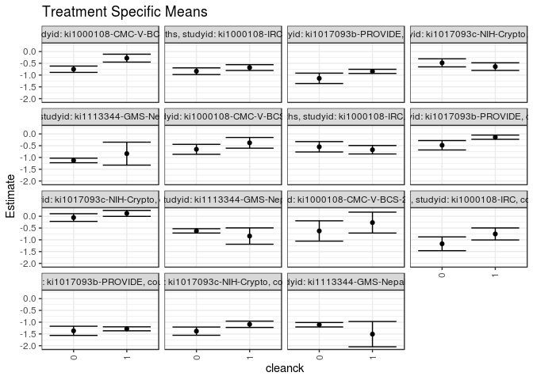

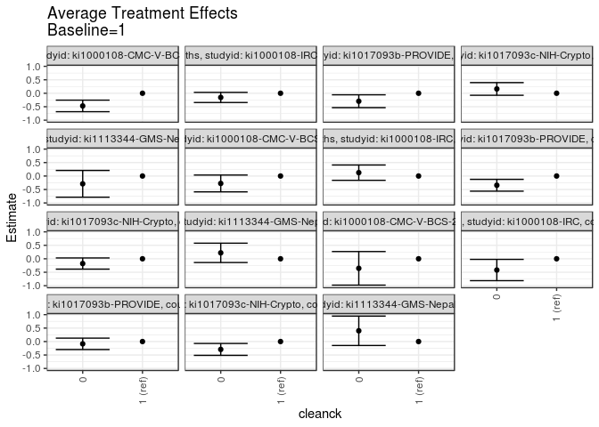

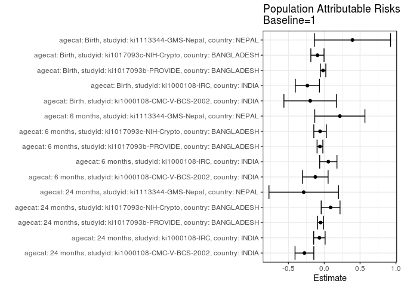

## Results Table

### Parameter: TSM

| agecat | studyid | country | intervention_level | baseline_level | estimate | ci_lower | ci_upper |
| --- | --- | --- | --- | --- | --- | --- | --- |
| Birth | ki1000108-CMC-V-BCS-2002 | INDIA | 1 | NA | -0.2686249 | -0.7125582 | 0.1753083 |
| Birth | ki1000108-CMC-V-BCS-2002 | INDIA | 0 | NA | -0.6235655 | -1.0554989 | -0.1916320 |
| Birth | ki1000108-IRC | INDIA | 1 | NA | -0.7508240 | -1.0058782 | -0.4957697 |
| Birth | ki1000108-IRC | INDIA | 0 | NA | -1.1685742 | -1.4619561 | -0.8751923 |
| Birth | ki1017093b-PROVIDE | BANGLADESH | 1 | NA | -1.2819881 | -1.3663628 | -1.1976133 |
| Birth | ki1017093b-PROVIDE | BANGLADESH | 0 | NA | -1.3669230 | -1.5613275 | -1.1725185 |
| Birth | ki1017093c-NIH-Crypto | BANGLADESH | 1 | NA | -1.0890426 | -1.2227184 | -0.9553668 |
| Birth | ki1017093c-NIH-Crypto | BANGLADESH | 0 | NA | -1.3814741 | -1.5564120 | -1.2065361 |
| Birth | ki1113344-GMS-Nepal | NEPAL | 1 | NA | -1.5077778 | -2.0451921 | -0.9703635 |
| Birth | ki1113344-GMS-Nepal | NEPAL | 0 | NA | -1.1081283 | -1.2024430 | -1.0138137 |
| 6 months | ki1000108-CMC-V-BCS-2002 | INDIA | 1 | NA | -0.3780399 | -0.6059984 | -0.1500813 |
| 6 months | ki1000108-CMC-V-BCS-2002 | INDIA | 0 | NA | -0.6539670 | -0.8663169 | -0.4416170 |
| 6 months | ki1000108-IRC | INDIA | 1 | NA | -0.6721941 | -0.8520701 | -0.4923181 |
| 6 months | ki1000108-IRC | INDIA | 0 | NA | -0.5470062 | -0.7672334 | -0.3267790 |
| 6 months | ki1017093b-PROVIDE | BANGLADESH | 1 | NA | -0.1389612 | -0.2286783 | -0.0492440 |
| 6 months | ki1017093b-PROVIDE | BANGLADESH | 0 | NA | -0.4819854 | -0.6823276 | -0.2816432 |
| 6 months | ki1017093c-NIH-Crypto | BANGLADESH | 1 | NA | 0.1223065 | -0.0040818 | 0.2486949 |
| 6 months | ki1017093c-NIH-Crypto | BANGLADESH | 0 | NA | -0.0544163 | -0.2169902 | 0.1081576 |
| 6 months | ki1113344-GMS-Nepal | NEPAL | 1 | NA | -0.8406250 | -1.1876486 | -0.4936014 |
| 6 months | ki1113344-GMS-Nepal | NEPAL | 0 | NA | -0.6195607 | -0.7114689 | -0.5276524 |
| 24 months | ki1000108-CMC-V-BCS-2002 | INDIA | 1 | NA | -0.2802978 | -0.4473752 | -0.1132204 |
| 24 months | ki1000108-CMC-V-BCS-2002 | INDIA | 0 | NA | -0.7512840 | -0.8855556 | -0.6170123 |
| 24 months | ki1000108-IRC | INDIA | 1 | NA | -0.6802511 | -0.8038984 | -0.5566037 |
| 24 months | ki1000108-IRC | INDIA | 0 | NA | -0.8352994 | -0.9769453 | -0.6936535 |
| 24 months | ki1017093b-PROVIDE | BANGLADESH | 1 | NA | -0.8420683 | -0.9302854 | -0.7538512 |
| 24 months | ki1017093b-PROVIDE | BANGLADESH | 0 | NA | -1.1385003 | -1.3594801 | -0.9175205 |
| 24 months | ki1017093c-NIH-Crypto | BANGLADESH | 1 | NA | -0.6404616 | -0.8023170 | -0.4786062 |
| 24 months | ki1017093c-NIH-Crypto | BANGLADESH | 0 | NA | -0.4804208 | -0.6512268 | -0.3096148 |
| 24 months | ki1113344-GMS-Nepal | NEPAL | 1 | NA | -0.8380000 | -1.3259702 | -0.3500298 |
| 24 months | ki1113344-GMS-Nepal | NEPAL | 0 | NA | -1.1280730 | -1.2245191 | -1.0316270 |

### Parameter: E(Y)

| agecat | studyid | country | intervention_level | baseline_level | estimate | ci_lower | ci_upper |
| --- | --- | --- | --- | --- | --- | --- | --- |
| Birth | ki1000108-CMC-V-BCS-2002 | INDIA | NA | NA | -0.4648256 | -0.7643210 | -0.1653302 |
| Birth | ki1000108-IRC | INDIA | NA | NA | -0.9860831 | -1.1746070 | -0.7975591 |
| Birth | ki1017093b-PROVIDE | BANGLADESH | NA | NA | -1.2984586 | -1.3752758 | -1.2216415 |
| Birth | ki1017093c-NIH-Crypto | BANGLADESH | NA | NA | -1.1841160 | -1.2799097 | -1.0883224 |
| Birth | ki1113344-GMS-Nepal | NEPAL | NA | NA | -1.1144386 | -1.2074618 | -1.0214154 |
| 6 months | ki1000108-CMC-V-BCS-2002 | INDIA | NA | NA | -0.5026766 | -0.6536848 | -0.3516685 |
| 6 months | ki1000108-IRC | INDIA | NA | NA | -0.6153685 | -0.7522411 | -0.4784959 |
| 6 months | ki1017093b-PROVIDE | BANGLADESH | NA | NA | -0.1990907 | -0.2817968 | -0.1163845 |
| 6 months | ki1017093c-NIH-Crypto | BANGLADESH | NA | NA | 0.0640826 | -0.0252594 | 0.1534245 |
| 6 months | ki1113344-GMS-Nepal | NEPAL | NA | NA | -0.6230627 | -0.7131245 | -0.5330009 |
| 24 months | ki1000108-CMC-V-BCS-2002 | INDIA | NA | NA | -0.5571505 | -0.6585247 | -0.4557763 |
| 24 months | ki1000108-IRC | INDIA | NA | NA | -0.7479083 | -0.8403586 | -0.6554581 |
| 24 months | ki1017093b-PROVIDE | BANGLADESH | NA | NA | -0.8928670 | -0.9755153 | -0.8102187 |
| 24 months | ki1017093c-NIH-Crypto | BANGLADESH | NA | NA | -0.5518293 | -0.6602513 | -0.4434072 |
| 24 months | ki1113344-GMS-Nepal | NEPAL | NA | NA | -1.1247312 | -1.2195989 | -1.0298635 |

### Parameter: ATE

| agecat | studyid | country | intervention_level | baseline_level | estimate | ci_lower | ci_upper |
| --- | --- | --- | --- | --- | --- | --- | --- |
| Birth | ki1000108-CMC-V-BCS-2002 | INDIA | 1 | 1 | 0.0000000 | 0.0000000 | 0.0000000 |
| Birth | ki1000108-CMC-V-BCS-2002 | INDIA | 0 | 1 | -0.3549405 | -0.9785996 | 0.2687185 |
| Birth | ki1000108-IRC | INDIA | 1 | 1 | 0.0000000 | 0.0000000 | 0.0000000 |
| Birth | ki1000108-IRC | INDIA | 0 | 1 | -0.4177502 | -0.8133160 | -0.0221845 |
| Birth | ki1017093b-PROVIDE | BANGLADESH | 1 | 1 | 0.0000000 | 0.0000000 | 0.0000000 |
| Birth | ki1017093b-PROVIDE | BANGLADESH | 0 | 1 | -0.0849349 | -0.2970484 | 0.1271785 |
| Birth | ki1017093c-NIH-Crypto | BANGLADESH | 1 | 1 | 0.0000000 | 0.0000000 | 0.0000000 |
| Birth | ki1017093c-NIH-Crypto | BANGLADESH | 0 | 1 | -0.2924315 | -0.5131661 | -0.0716969 |
| Birth | ki1113344-GMS-Nepal | NEPAL | 1 | 1 | 0.0000000 | 0.0000000 | 0.0000000 |
| Birth | ki1113344-GMS-Nepal | NEPAL | 0 | 1 | 0.3996494 | -0.1459781 | 0.9452770 |
| 6 months | ki1000108-CMC-V-BCS-2002 | INDIA | 1 | 1 | 0.0000000 | 0.0000000 | 0.0000000 |
| 6 months | ki1000108-CMC-V-BCS-2002 | INDIA | 0 | 1 | -0.2759271 | -0.5882577 | 0.0364035 |
| 6 months | ki1000108-IRC | INDIA | 1 | 1 | 0.0000000 | 0.0000000 | 0.0000000 |
| 6 months | ki1000108-IRC | INDIA | 0 | 1 | 0.1251879 | -0.1593807 | 0.4097564 |
| 6 months | ki1017093b-PROVIDE | BANGLADESH | 1 | 1 | 0.0000000 | 0.0000000 | 0.0000000 |
| 6 months | ki1017093b-PROVIDE | BANGLADESH | 0 | 1 | -0.3430242 | -0.5624011 | -0.1236474 |
| 6 months | ki1017093c-NIH-Crypto | BANGLADESH | 1 | 1 | 0.0000000 | 0.0000000 | 0.0000000 |
| 6 months | ki1017093c-NIH-Crypto | BANGLADESH | 0 | 1 | -0.1767228 | -0.3842995 | 0.0308538 |
| 6 months | ki1113344-GMS-Nepal | NEPAL | 1 | 1 | 0.0000000 | 0.0000000 | 0.0000000 |
| 6 months | ki1113344-GMS-Nepal | NEPAL | 0 | 1 | 0.2210643 | -0.1379239 | 0.5800525 |
| 24 months | ki1000108-CMC-V-BCS-2002 | INDIA | 1 | 1 | 0.0000000 | 0.0000000 | 0.0000000 |
| 24 months | ki1000108-CMC-V-BCS-2002 | INDIA | 0 | 1 | -0.4709862 | -0.6860365 | -0.2559358 |
| 24 months | ki1000108-IRC | INDIA | 1 | 1 | 0.0000000 | 0.0000000 | 0.0000000 |
| 24 months | ki1000108-IRC | INDIA | 0 | 1 | -0.1550483 | -0.3435038 | 0.0334072 |
| 24 months | ki1017093b-PROVIDE | BANGLADESH | 1 | 1 | 0.0000000 | 0.0000000 | 0.0000000 |
| 24 months | ki1017093b-PROVIDE | BANGLADESH | 0 | 1 | -0.2964320 | -0.5347168 | -0.0581472 |
| 24 months | ki1017093c-NIH-Crypto | BANGLADESH | 1 | 1 | 0.0000000 | 0.0000000 | 0.0000000 |
| 24 months | ki1017093c-NIH-Crypto | BANGLADESH | 0 | 1 | 0.1600408 | -0.0753322 | 0.3954139 |
| 24 months | ki1113344-GMS-Nepal | NEPAL | 1 | 1 | 0.0000000 | 0.0000000 | 0.0000000 |
| 24 months | ki1113344-GMS-Nepal | NEPAL | 0 | 1 | -0.2900730 | -0.7874831 | 0.2073370 |

### Parameter: PAR

| agecat | studyid | country | intervention_level | baseline_level | estimate | ci_lower | ci_upper |
| --- | --- | --- | --- | --- | --- | --- | --- |
| Birth | ki1000108-CMC-V-BCS-2002 | INDIA | 1 | NA | -0.1962007 | -0.5629649 | 0.1705636 |
| Birth | ki1000108-IRC | INDIA | 1 | NA | -0.2352591 | -0.4040348 | -0.0664834 |
| Birth | ki1017093b-PROVIDE | BANGLADESH | 1 | NA | -0.0164706 | -0.0547267 | 0.0217856 |
| Birth | ki1017093c-NIH-Crypto | BANGLADESH | 1 | NA | -0.0950734 | -0.1870712 | -0.0030756 |
| Birth | ki1113344-GMS-Nepal | NEPAL | 1 | NA | 0.3933392 | -0.1386634 | 0.9253418 |
| 6 months | ki1000108-CMC-V-BCS-2002 | INDIA | 1 | NA | -0.1246368 | -0.3029988 | 0.0537253 |
| 6 months | ki1000108-IRC | INDIA | 1 | NA | 0.0568256 | -0.0636093 | 0.1772604 |
| 6 months | ki1017093b-PROVIDE | BANGLADESH | 1 | NA | -0.0601295 | -0.1002981 | -0.0199609 |
| 6 months | ki1017093c-NIH-Crypto | BANGLADESH | 1 | NA | -0.0582240 | -0.1456567 | 0.0292087 |
| 6 months | ki1113344-GMS-Nepal | NEPAL | 1 | NA | 0.2175623 | -0.1324595 | 0.5675841 |
| 24 months | ki1000108-CMC-V-BCS-2002 | INDIA | 1 | NA | -0.2768527 | -0.4078591 | -0.1458464 |
| 24 months | ki1000108-IRC | INDIA | 1 | NA | -0.0676573 | -0.1472650 | 0.0119505 |
| 24 months | ki1017093b-PROVIDE | BANGLADESH | 1 | NA | -0.0507987 | -0.0925713 | -0.0090261 |
| 24 months | ki1017093c-NIH-Crypto | BANGLADESH | 1 | NA | 0.0886323 | -0.0428385 | 0.2201032 |
| 24 months | ki1113344-GMS-Nepal | NEPAL | 1 | NA | -0.2867312 | -0.7717148 | 0.1982524 |